# Risk Factor Analysis

## Outcome Variable

**Outcome Variable:** y_rate_len

## Predictor Variables

**Intervention Variable:** hdlvry

**Adjustment Set:**

- arm
- sex
- W_mage
- meducyrs
- feducyrs
- W_nrooms
- brthmon
- W_parity
- impsan
- delta_W_mage
- delta_meducyrs
- delta_feducyrs
- delta_W_nrooms
- delta_brthmon
- delta_W_parity
- delta_impsan

## Stratifying Variables

The analysis was stratified on these variable(s):

- agecat
- studyid
- country

## Data Summary

| agecat | studyid | country | hdlvry | n_cell | n |
| --- | --- | --- | --- | --- | --- |
| 0-3 months | ki1017093b-PROVIDE | BANGLADESH | 0 | 474 | 634 |
| 0-3 months | ki1017093b-PROVIDE | BANGLADESH | 1 | 160 | 634 |
| 0-3 months | ki1017093c-NIH-Crypto | BANGLADESH | 0 | 557 | 720 |
| 0-3 months | ki1017093c-NIH-Crypto | BANGLADESH | 1 | 163 | 720 |
| 0-3 months | kiGH5241-JiVitA-3 | BANGLADESH | 0 | 33 | 313 |
| 0-3 months | kiGH5241-JiVitA-3 | BANGLADESH | 1 | 280 | 313 |
| 0-3 months | kiGH5241-JiVitA-4 | BANGLADESH | 0 | 369 | 1796 |
| 0-3 months | kiGH5241-JiVitA-4 | BANGLADESH | 1 | 1427 | 1796 |
| 0-3 months | ki1000108-CMC-V-BCS-2002 | INDIA | 0 | 87 | 87 |
| 0-3 months | ki1000108-IRC | INDIA | 0 | 370 | 377 |
| 0-3 months | ki1000108-IRC | INDIA | 1 | 7 | 377 |
| 0-3 months | ki1000304b-SAS-CompFeed | INDIA | 0 | 127 | 976 |
| 0-3 months | ki1000304b-SAS-CompFeed | INDIA | 1 | 849 | 976 |
| 0-3 months | ki1135781-COHORTS | INDIA | 0 | 2863 | 4580 |
| 0-3 months | ki1135781-COHORTS | INDIA | 1 | 1717 | 4580 |
| 0-3 months | ki1000109-EE | PAKISTAN | 0 | 193 | 295 |
| 0-3 months | ki1000109-EE | PAKISTAN | 1 | 102 | 295 |
| 3-6 months | ki1017093b-PROVIDE | BANGLADESH | 0 | 428 | 574 |
| 3-6 months | ki1017093b-PROVIDE | BANGLADESH | 1 | 146 | 574 |
| 3-6 months | ki1017093c-NIH-Crypto | BANGLADESH | 0 | 536 | 695 |
| 3-6 months | ki1017093c-NIH-Crypto | BANGLADESH | 1 | 159 | 695 |
| 3-6 months | kiGH5241-JiVitA-3 | BANGLADESH | 0 | 28 | 275 |
| 3-6 months | kiGH5241-JiVitA-3 | BANGLADESH | 1 | 247 | 275 |
| 3-6 months | kiGH5241-JiVitA-4 | BANGLADESH | 0 | 412 | 1752 |
| 3-6 months | kiGH5241-JiVitA-4 | BANGLADESH | 1 | 1340 | 1752 |
| 3-6 months | ki1000108-CMC-V-BCS-2002 | INDIA | 0 | 298 | 305 |
| 3-6 months | ki1000108-CMC-V-BCS-2002 | INDIA | 1 | 7 | 305 |
| 3-6 months | ki1000108-IRC | INDIA | 0 | 389 | 397 |
| 3-6 months | ki1000108-IRC | INDIA | 1 | 8 | 397 |
| 3-6 months | ki1000304b-SAS-CompFeed | INDIA | 0 | 124 | 919 |
| 3-6 months | ki1000304b-SAS-CompFeed | INDIA | 1 | 795 | 919 |
| 3-6 months | ki1135781-COHORTS | INDIA | 0 | 2754 | 4481 |
| 3-6 months | ki1135781-COHORTS | INDIA | 1 | 1727 | 4481 |
| 3-6 months | ki1113344-GMS-Nepal | NEPAL | 0 | 102 | 438 |
| 3-6 months | ki1113344-GMS-Nepal | NEPAL | 1 | 336 | 438 |
| 3-6 months | ki1000109-EE | PAKISTAN | 0 | 218 | 329 |
| 3-6 months | ki1000109-EE | PAKISTAN | 1 | 111 | 329 |
| 3-6 months | ki1066203-TanzaniaChild2 | TANZANIA, UNITED REPUBLIC OF | 0 | 1549 | 1577 |
| 3-6 months | ki1066203-TanzaniaChild2 | TANZANIA, UNITED REPUBLIC OF | 1 | 28 | 1577 |
| 6-12 months | ki1017093b-PROVIDE | BANGLADESH | 0 | 404 | 545 |
| 6-12 months | ki1017093b-PROVIDE | BANGLADESH | 1 | 141 | 545 |
| 6-12 months | ki1017093c-NIH-Crypto | BANGLADESH | 0 | 523 | 676 |
| 6-12 months | ki1017093c-NIH-Crypto | BANGLADESH | 1 | 153 | 676 |
| 6-12 months | kiGH5241-JiVitA-3 | BANGLADESH | 0 | 29 | 243 |
| 6-12 months | kiGH5241-JiVitA-3 | BANGLADESH | 1 | 214 | 243 |
| 6-12 months | kiGH5241-JiVitA-4 | BANGLADESH | 0 | 750 | 2803 |
| 6-12 months | kiGH5241-JiVitA-4 | BANGLADESH | 1 | 2053 | 2803 |
| 6-12 months | ki1000108-CMC-V-BCS-2002 | INDIA | 0 | 314 | 321 |
| 6-12 months | ki1000108-CMC-V-BCS-2002 | INDIA | 1 | 7 | 321 |
| 6-12 months | ki1000108-IRC | INDIA | 0 | 392 | 400 |
| 6-12 months | ki1000108-IRC | INDIA | 1 | 8 | 400 |
| 6-12 months | ki1000304b-SAS-CompFeed | INDIA | 0 | 131 | 936 |
| 6-12 months | ki1000304b-SAS-CompFeed | INDIA | 1 | 805 | 936 |
| 6-12 months | ki1000304b-SAS-FoodSuppl | INDIA | 0 | 67 | 332 |
| 6-12 months | ki1000304b-SAS-FoodSuppl | INDIA | 1 | 265 | 332 |
| 6-12 months | ki1135781-COHORTS | INDIA | 0 | 2239 | 3598 |
| 6-12 months | ki1135781-COHORTS | INDIA | 1 | 1359 | 3598 |
| 6-12 months | ki1113344-GMS-Nepal | NEPAL | 0 | 105 | 446 |
| 6-12 months | ki1113344-GMS-Nepal | NEPAL | 1 | 341 | 446 |
| 6-12 months | ki1000109-EE | PAKISTAN | 0 | 4 | 4 |
| 6-12 months | ki1066203-TanzaniaChild2 | TANZANIA, UNITED REPUBLIC OF | 0 | 1015 | 1025 |
| 6-12 months | ki1066203-TanzaniaChild2 | TANZANIA, UNITED REPUBLIC OF | 1 | 10 | 1025 |
| 12-24 months | ki1017093b-PROVIDE | BANGLADESH | 0 | 340 | 458 |
| 12-24 months | ki1017093b-PROVIDE | BANGLADESH | 1 | 118 | 458 |
| 12-24 months | ki1017093c-NIH-Crypto | BANGLADESH | 0 | 379 | 495 |
| 12-24 months | ki1017093c-NIH-Crypto | BANGLADESH | 1 | 116 | 495 |
| 12-24 months | kiGH5241-JiVitA-3 | BANGLADESH | 0 | 24 | 191 |
| 12-24 months | kiGH5241-JiVitA-3 | BANGLADESH | 1 | 167 | 191 |
| 12-24 months | kiGH5241-JiVitA-4 | BANGLADESH | 0 | 805 | 3107 |
| 12-24 months | kiGH5241-JiVitA-4 | BANGLADESH | 1 | 2302 | 3107 |
| 12-24 months | ki1000108-CMC-V-BCS-2002 | INDIA | 0 | 315 | 322 |
| 12-24 months | ki1000108-CMC-V-BCS-2002 | INDIA | 1 | 7 | 322 |
| 12-24 months | ki1000108-IRC | INDIA | 0 | 388 | 396 |
| 12-24 months | ki1000108-IRC | INDIA | 1 | 8 | 396 |
| 12-24 months | ki1135781-COHORTS | INDIA | 0 | 1876 | 2999 |
| 12-24 months | ki1135781-COHORTS | INDIA | 1 | 1123 | 2999 |
| 12-24 months | ki1113344-GMS-Nepal | NEPAL | 0 | 86 | 341 |
| 12-24 months | ki1113344-GMS-Nepal | NEPAL | 1 | 255 | 341 |
| 12-24 months | ki1066203-TanzaniaChild2 | TANZANIA, UNITED REPUBLIC OF | 0 | 2 | 2 |

The following strata were considered:

- agecat: 0-3 months, studyid: ki1000108-CMC-V-BCS-2002, country: INDIA
- agecat: 0-3 months, studyid: ki1000108-IRC, country: INDIA
- agecat: 0-3 months, studyid: ki1000109-EE, country: PAKISTAN
- agecat: 0-3 months, studyid: ki1000304b-SAS-CompFeed, country: INDIA
- agecat: 0-3 months, studyid: ki1017093b-PROVIDE, country: BANGLADESH
- agecat: 0-3 months, studyid: ki1017093c-NIH-Crypto, country: BANGLADESH
- agecat: 0-3 months, studyid: ki1135781-COHORTS, country: INDIA
- agecat: 0-3 months, studyid: kiGH5241-JiVitA-3, country: BANGLADESH
- agecat: 0-3 months, studyid: kiGH5241-JiVitA-4, country: BANGLADESH
- agecat: 12-24 months, studyid: ki1000108-CMC-V-BCS-2002, country: INDIA
- agecat: 12-24 months, studyid: ki1000108-IRC, country: INDIA
- agecat: 12-24 months, studyid: ki1017093b-PROVIDE, country: BANGLADESH
- agecat: 12-24 months, studyid: ki1017093c-NIH-Crypto, country: BANGLADESH
- agecat: 12-24 months, studyid: ki1066203-TanzaniaChild2, country: TANZANIA, UNITED REPUBLIC OF
- agecat: 12-24 months, studyid: ki1113344-GMS-Nepal, country: NEPAL
- agecat: 12-24 months, studyid: ki1135781-COHORTS, country: INDIA
- agecat: 12-24 months, studyid: kiGH5241-JiVitA-3, country: BANGLADESH
- agecat: 12-24 months, studyid: kiGH5241-JiVitA-4, country: BANGLADESH
- agecat: 3-6 months, studyid: ki1000108-CMC-V-BCS-2002, country: INDIA
- agecat: 3-6 months, studyid: ki1000108-IRC, country: INDIA
- agecat: 3-6 months, studyid: ki1000109-EE, country: PAKISTAN
- agecat: 3-6 months, studyid: ki1000304b-SAS-CompFeed, country: INDIA
- agecat: 3-6 months, studyid: ki1017093b-PROVIDE, country: BANGLADESH
- agecat: 3-6 months, studyid: ki1017093c-NIH-Crypto, country: BANGLADESH
- agecat: 3-6 months, studyid: ki1066203-TanzaniaChild2, country: TANZANIA, UNITED REPUBLIC OF
- agecat: 3-6 months, studyid: ki1113344-GMS-Nepal, country: NEPAL
- agecat: 3-6 months, studyid: ki1135781-COHORTS, country: INDIA
- agecat: 3-6 months, studyid: kiGH5241-JiVitA-3, country: BANGLADESH
- agecat: 3-6 months, studyid: kiGH5241-JiVitA-4, country: BANGLADESH
- agecat: 6-12 months, studyid: ki1000108-CMC-V-BCS-2002, country: INDIA
- agecat: 6-12 months, studyid: ki1000108-IRC, country: INDIA
- agecat: 6-12 months, studyid: ki1000109-EE, country: PAKISTAN
- agecat: 6-12 months, studyid: ki1000304b-SAS-CompFeed, country: INDIA
- agecat: 6-12 months, studyid: ki1000304b-SAS-FoodSuppl, country: INDIA
- agecat: 6-12 months, studyid: ki1017093b-PROVIDE, country: BANGLADESH
- agecat: 6-12 months, studyid: ki1017093c-NIH-Crypto, country: BANGLADESH
- agecat: 6-12 months, studyid: ki1066203-TanzaniaChild2, country: TANZANIA, UNITED REPUBLIC OF
- agecat: 6-12 months, studyid: ki1113344-GMS-Nepal, country: NEPAL
- agecat: 6-12 months, studyid: ki1135781-COHORTS, country: INDIA
- agecat: 6-12 months, studyid: kiGH5241-JiVitA-3, country: BANGLADESH
- agecat: 6-12 months, studyid: kiGH5241-JiVitA-4, country: BANGLADESH

## Methods Detail

We’re interested in the causal parameters $E[Y_a]$ for all values of $a \in \mathcal{A}$. These parameters represent the mean outcome if, possibly contrary to fact, we intervened to set all units to have $A=a$. Under the randomization and positivity assumptions, these are identified by the statistical parameters $\psi_a=E_W[E_{Y|A,W}(Y|A=a,W)]$. In addition, we’re interested in the mean of $Y$, $E[Y]$ under no intervention (the observed mean). We will estimate these parameters by using SuperLearner to fit the relevant likelihood factors – $E_{Y|A,W}(Y|A=a,W)$ and $p(A=a|W)$, and then updating our likelihood fit using a joint TMLE.

For unadjusted analyses ($W=\{\}$), initial likelihoods were estimated using Lrnr_glm to estimate the simple $E(Y|A)$ and Lrnr_mean to estimate $p(A)$. For adjusted analyses, a small library containing Lrnr_glmnet, Lrnr_xgboost, and Lrnr_mean was used.

Having estimated these parameters, we will then use the delta method to estimate relative risks and attributable risks relative to a prespecified baseline level of $A$.

[output not shown]

[output cut: 17 more lines]

[output not shown]

# Results Detail

## Results Plots

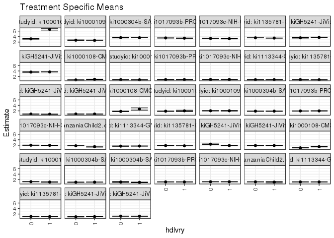

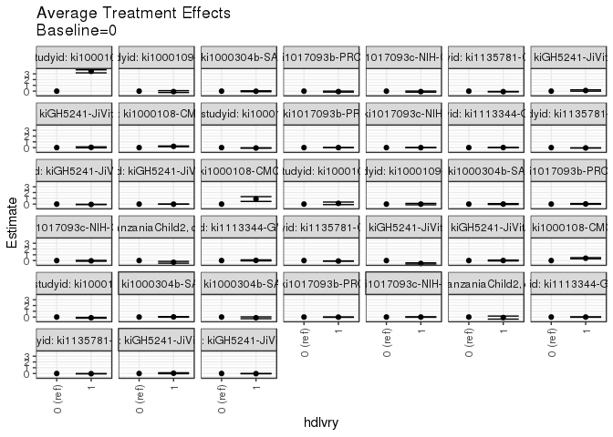

## Results Table

### Parameter: TSM

| agecat | studyid | country | intervention_level | baseline_level | estimate | ci_lower | ci_upper |
| --- | --- | --- | --- | --- | --- | --- | --- |
| 0-3 months | ki1000108-IRC | INDIA | 0 | NA | 3.1789304 | 3.0659858 | 3.2918750 |
| 0-3 months | ki1000108-IRC | INDIA | 1 | NA | 6.6154444 | 6.3782513 | 6.8526375 |
| 0-3 months | ki1000109-EE | PAKISTAN | 0 | NA | 2.6858064 | 2.5743416 | 2.7972712 |
| 0-3 months | ki1000109-EE | PAKISTAN | 1 | NA | 2.6067612 | 2.4898170 | 2.7237055 |
| 0-3 months | ki1000304b-SAS-CompFeed | INDIA | 0 | NA | 3.6056019 | 3.5232379 | 3.6879659 |
| 0-3 months | ki1000304b-SAS-CompFeed | INDIA | 1 | NA | 3.5897844 | 3.5656618 | 3.6139070 |
| 0-3 months | ki1017093b-PROVIDE | BANGLADESH | 0 | NA | 3.5063428 | 3.4604220 | 3.5522636 |
| 0-3 months | ki1017093b-PROVIDE | BANGLADESH | 1 | NA | 3.4295262 | 3.3610340 | 3.4980184 |
| 0-3 months | ki1017093c-NIH-Crypto | BANGLADESH | 0 | NA | 3.3212397 | 3.2778135 | 3.3646659 |
| 0-3 months | ki1017093c-NIH-Crypto | BANGLADESH | 1 | NA | 3.2400782 | 3.1606053 | 3.3195510 |
| 0-3 months | ki1135781-COHORTS | INDIA | 0 | NA | 3.5566613 | 3.5352933 | 3.5780294 |
| 0-3 months | ki1135781-COHORTS | INDIA | 1 | NA | 3.4696957 | 3.4441654 | 3.4952260 |
| 0-3 months | kiGH5241-JiVitA-3 | BANGLADESH | 0 | NA | 3.5639363 | 3.4583393 | 3.6695332 |
| 0-3 months | kiGH5241-JiVitA-3 | BANGLADESH | 1 | NA | 3.6750426 | 3.6127184 | 3.7373668 |
| 0-3 months | kiGH5241-JiVitA-4 | BANGLADESH | 0 | NA | 3.6038965 | 3.5186583 | 3.6891348 |
| 0-3 months | kiGH5241-JiVitA-4 | BANGLADESH | 1 | NA | 3.6467191 | 3.6138419 | 3.6795963 |
| 3-6 months | ki1000108-CMC-V-BCS-2002 | INDIA | 0 | NA | 1.8067171 | 1.7046174 | 1.9088169 |
| 3-6 months | ki1000108-CMC-V-BCS-2002 | INDIA | 1 | NA | 2.6822887 | 2.2763972 | 3.0881801 |
| 3-6 months | ki1000108-IRC | INDIA | 0 | NA | 1.8827130 | 1.8180383 | 1.9473877 |
| 3-6 months | ki1000108-IRC | INDIA | 1 | NA | 2.0089887 | 1.7994005 | 2.2185769 |
| 3-6 months | ki1000109-EE | PAKISTAN | 0 | NA | 2.0263221 | 1.9523514 | 2.1002928 |
| 3-6 months | ki1000109-EE | PAKISTAN | 1 | NA | 2.0233321 | 1.9270037 | 2.1196605 |
| 3-6 months | ki1000304b-SAS-CompFeed | INDIA | 0 | NA | 1.8950366 | 1.8499484 | 1.9401248 |
| 3-6 months | ki1000304b-SAS-CompFeed | INDIA | 1 | NA | 1.8981568 | 1.8295926 | 1.9667211 |
| 3-6 months | ki1017093b-PROVIDE | BANGLADESH | 0 | NA | 1.9614711 | 1.9217265 | 2.0012156 |
| 3-6 months | ki1017093b-PROVIDE | BANGLADESH | 1 | NA | 1.9845510 | 1.9257867 | 2.0433154 |
| 3-6 months | ki1017093c-NIH-Crypto | BANGLADESH | 0 | NA | 2.0163548 | 1.9746556 | 2.0580541 |
| 3-6 months | ki1017093c-NIH-Crypto | BANGLADESH | 1 | NA | 1.9716479 | 1.9085409 | 2.0347548 |
| 3-6 months | ki1066203-TanzaniaChild2 | TANZANIA, UNITED REPUBLIC OF | 0 | NA | 1.7924091 | 1.7553947 | 1.8294235 |
| 3-6 months | ki1066203-TanzaniaChild2 | TANZANIA, UNITED REPUBLIC OF | 1 | NA | 1.4922268 | 1.3355119 | 1.6489416 |
| 3-6 months | ki1113344-GMS-Nepal | NEPAL | 0 | NA | 1.6794277 | 1.6068624 | 1.7519929 |
| 3-6 months | ki1113344-GMS-Nepal | NEPAL | 1 | NA | 1.7079489 | 1.6612568 | 1.7546409 |
| 3-6 months | ki1135781-COHORTS | INDIA | 0 | NA | 1.8728281 | 1.8544739 | 1.8911823 |
| 3-6 months | ki1135781-COHORTS | INDIA | 1 | NA | 1.7882429 | 1.7664401 | 1.8100456 |
| 3-6 months | kiGH5241-JiVitA-3 | BANGLADESH | 0 | NA | 2.3919368 | 2.3065640 | 2.4773097 |
| 3-6 months | kiGH5241-JiVitA-3 | BANGLADESH | 1 | NA | 1.8864611 | 1.8241682 | 1.9487540 |
| 3-6 months | kiGH5241-JiVitA-4 | BANGLADESH | 0 | NA | 1.8861857 | 1.8175594 | 1.9548119 |
| 3-6 months | kiGH5241-JiVitA-4 | BANGLADESH | 1 | NA | 1.8970714 | 1.8650962 | 1.9290465 |
| 6-12 months | ki1000108-CMC-V-BCS-2002 | INDIA | 0 | NA | 1.0594443 | 1.0106146 | 1.1082740 |
| 6-12 months | ki1000108-CMC-V-BCS-2002 | INDIA | 1 | NA | 1.4637685 | 1.3703105 | 1.5572265 |
| 6-12 months | ki1000108-IRC | INDIA | 0 | NA | 1.2495319 | 1.2200107 | 1.2790531 |
| 6-12 months | ki1000108-IRC | INDIA | 1 | NA | 1.1219697 | 1.0558716 | 1.1880679 |
| 6-12 months | ki1000304b-SAS-CompFeed | INDIA | 0 | NA | 1.0719693 | 1.0290355 | 1.1149031 |
| 6-12 months | ki1000304b-SAS-CompFeed | INDIA | 1 | NA | 1.0926555 | 1.0758028 | 1.1095081 |
| 6-12 months | ki1000304b-SAS-FoodSuppl | INDIA | 0 | NA | 1.1434660 | 1.0067742 | 1.2801578 |
| 6-12 months | ki1000304b-SAS-FoodSuppl | INDIA | 1 | NA | 1.0151455 | 0.9330696 | 1.0972214 |
| 6-12 months | ki1017093b-PROVIDE | BANGLADESH | 0 | NA | 1.1778831 | 1.1576564 | 1.1981098 |
| 6-12 months | ki1017093b-PROVIDE | BANGLADESH | 1 | NA | 1.1615434 | 1.1297090 | 1.1933777 |
| 6-12 months | ki1017093c-NIH-Crypto | BANGLADESH | 0 | NA | 1.2283540 | 1.2084313 | 1.2482766 |
| 6-12 months | ki1017093c-NIH-Crypto | BANGLADESH | 1 | NA | 1.2257892 | 1.1934148 | 1.2581637 |
| 6-12 months | ki1066203-TanzaniaChild2 | TANZANIA, UNITED REPUBLIC OF | 0 | NA | 1.1948428 | 1.1728538 | 1.2168317 |
| 6-12 months | ki1066203-TanzaniaChild2 | TANZANIA, UNITED REPUBLIC OF | 1 | NA | 1.0990344 | 0.8379901 | 1.3600787 |
| 6-12 months | ki1113344-GMS-Nepal | NEPAL | 0 | NA | 1.1666552 | 1.1322832 | 1.2010272 |
| 6-12 months | ki1113344-GMS-Nepal | NEPAL | 1 | NA | 1.1623539 | 1.1385124 | 1.1861954 |
| 6-12 months | ki1135781-COHORTS | INDIA | 0 | NA | 1.0976539 | 1.0853035 | 1.1100042 |
| 6-12 months | ki1135781-COHORTS | INDIA | 1 | NA | 1.0617253 | 1.0468558 | 1.0765948 |
| 6-12 months | kiGH5241-JiVitA-3 | BANGLADESH | 0 | NA | 1.0021253 | 0.9462046 | 1.0580460 |
| 6-12 months | kiGH5241-JiVitA-3 | BANGLADESH | 1 | NA | 1.0493910 | 0.9990123 | 1.0997697 |
| 6-12 months | kiGH5241-JiVitA-4 | BANGLADESH | 0 | NA | 1.2259584 | 1.2071732 | 1.2447436 |
| 6-12 months | kiGH5241-JiVitA-4 | BANGLADESH | 1 | NA | 1.1987030 | 1.1861918 | 1.2112142 |
| 12-24 months | ki1000108-CMC-V-BCS-2002 | INDIA | 0 | NA | 0.7399787 | 0.7132727 | 0.7666848 |
| 12-24 months | ki1000108-CMC-V-BCS-2002 | INDIA | 1 | NA | 0.9589005 | 0.9058235 | 1.0119776 |
| 12-24 months | ki1000108-IRC | INDIA | 0 | NA | 0.8305895 | 0.8108148 | 0.8503642 |
| 12-24 months | ki1000108-IRC | INDIA | 1 | NA | 0.7670844 | 0.7298705 | 0.8042983 |
| 12-24 months | ki1017093b-PROVIDE | BANGLADESH | 0 | NA | 0.8570774 | 0.8429765 | 0.8711783 |
| 12-24 months | ki1017093b-PROVIDE | BANGLADESH | 1 | NA | 0.8592530 | 0.8385183 | 0.8799876 |
| 12-24 months | ki1017093c-NIH-Crypto | BANGLADESH | 0 | NA | 0.8774859 | 0.8638942 | 0.8910777 |
| 12-24 months | ki1017093c-NIH-Crypto | BANGLADESH | 1 | NA | 0.8744885 | 0.8529991 | 0.8959778 |
| 12-24 months | ki1113344-GMS-Nepal | NEPAL | 0 | NA | 0.8229549 | 0.7995569 | 0.8463530 |
| 12-24 months | ki1113344-GMS-Nepal | NEPAL | 1 | NA | 0.8342984 | 0.8155808 | 0.8530160 |
| 12-24 months | ki1135781-COHORTS | INDIA | 0 | NA | 0.8349066 | 0.8277386 | 0.8420746 |
| 12-24 months | ki1135781-COHORTS | INDIA | 1 | NA | 0.7805914 | 0.7717358 | 0.7894470 |
| 12-24 months | kiGH5241-JiVitA-3 | BANGLADESH | 0 | NA | 0.8432048 | 0.8184945 | 0.8679150 |
| 12-24 months | kiGH5241-JiVitA-3 | BANGLADESH | 1 | NA | 0.7818700 | 0.7542430 | 0.8094970 |
| 12-24 months | kiGH5241-JiVitA-4 | BANGLADESH | 0 | NA | 0.8612841 | 0.8501254 | 0.8724428 |
| 12-24 months | kiGH5241-JiVitA-4 | BANGLADESH | 1 | NA | 0.8479741 | 0.8413275 | 0.8546208 |

### Parameter: E(Y)

| agecat | studyid | country | intervention_level | baseline_level | estimate | ci_lower | ci_upper |
| --- | --- | --- | --- | --- | --- | --- | --- |
| 0-3 months | ki1000108-IRC | INDIA | NA | NA | 3.1729204 | 3.0609523 | 3.2848884 |
| 0-3 months | ki1000109-EE | PAKISTAN | NA | NA | 2.6584728 | 2.5745279 | 2.7424177 |
| 0-3 months | ki1000304b-SAS-CompFeed | INDIA | NA | NA | 3.5978528 | 3.5675578 | 3.6281478 |
| 0-3 months | ki1017093b-PROVIDE | BANGLADESH | NA | NA | 3.4826706 | 3.4434873 | 3.5218539 |
| 0-3 months | ki1017093c-NIH-Crypto | BANGLADESH | NA | NA | 3.3028656 | 3.2646714 | 3.3410598 |
| 0-3 months | ki1135781-COHORTS | INDIA | NA | NA | 3.5316726 | 3.5145737 | 3.5487714 |
| 0-3 months | kiGH5241-JiVitA-3 | BANGLADESH | NA | NA | 3.6717783 | 3.6046717 | 3.7388850 |
| 0-3 months | kiGH5241-JiVitA-4 | BANGLADESH | NA | NA | 3.6373098 | 3.6059106 | 3.6687089 |
| 3-6 months | ki1000108-CMC-V-BCS-2002 | INDIA | NA | NA | 1.8090444 | 1.7078462 | 1.9102427 |
| 3-6 months | ki1000108-IRC | INDIA | NA | NA | 1.8806738 | 1.8168757 | 1.9444719 |
| 3-6 months | ki1000109-EE | PAKISTAN | NA | NA | 2.0257728 | 1.9650303 | 2.0865152 |
| 3-6 months | ki1000304b-SAS-CompFeed | INDIA | NA | NA | 1.9057893 | 1.8442152 | 1.9673633 |
| 3-6 months | ki1017093b-PROVIDE | BANGLADESH | NA | NA | 1.9654454 | 1.9303798 | 2.0005110 |
| 3-6 months | ki1017093c-NIH-Crypto | BANGLADESH | NA | NA | 2.0057973 | 1.9693775 | 2.0422170 |
| 3-6 months | ki1066203-TanzaniaChild2 | TANZANIA, UNITED REPUBLIC OF | NA | NA | 1.7898602 | 1.7530949 | 1.8266255 |
| 3-6 months | ki1113344-GMS-Nepal | NEPAL | NA | NA | 1.7124798 | 1.6715373 | 1.7534223 |
| 3-6 months | ki1135781-COHORTS | INDIA | NA | NA | 1.8571473 | 1.8427398 | 1.8715548 |
| 3-6 months | kiGH5241-JiVitA-3 | BANGLADESH | NA | NA | 1.8747997 | 1.8153916 | 1.9342078 |
| 3-6 months | kiGH5241-JiVitA-4 | BANGLADESH | NA | NA | 1.8985588 | 1.8677350 | 1.9293826 |
| 6-12 months | ki1000108-CMC-V-BCS-2002 | INDIA | NA | NA | 1.0631293 | 1.0151394 | 1.1111193 |
| 6-12 months | ki1000108-IRC | INDIA | NA | NA | 1.2485668 | 1.2193308 | 1.2778028 |
| 6-12 months | ki1000304b-SAS-CompFeed | INDIA | NA | NA | 1.0945527 | 1.0814129 | 1.1076925 |
| 6-12 months | ki1000304b-SAS-FoodSuppl | INDIA | NA | NA | 1.0131058 | 0.9370457 | 1.0891660 |
| 6-12 months | ki1017093b-PROVIDE | BANGLADESH | NA | NA | 1.1731762 | 1.1558671 | 1.1904853 |
| 6-12 months | ki1017093c-NIH-Crypto | BANGLADESH | NA | NA | 1.2281313 | 1.2106849 | 1.2455776 |
| 6-12 months | ki1066203-TanzaniaChild2 | TANZANIA, UNITED REPUBLIC OF | NA | NA | 1.1937602 | 1.1717617 | 1.2157587 |
| 6-12 months | ki1113344-GMS-Nepal | NEPAL | NA | NA | 1.1671480 | 1.1467111 | 1.1875848 |
| 6-12 months | ki1135781-COHORTS | INDIA | NA | NA | 1.0832218 | 1.0732207 | 1.0932230 |
| 6-12 months | kiGH5241-JiVitA-3 | BANGLADESH | NA | NA | 1.0536838 | 1.0105552 | 1.0968123 |
| 6-12 months | kiGH5241-JiVitA-4 | BANGLADESH | NA | NA | 1.2059812 | 1.1951907 | 1.2167718 |
| 12-24 months | ki1000108-CMC-V-BCS-2002 | INDIA | NA | NA | 0.7380528 | 0.7116168 | 0.7644888 |
| 12-24 months | ki1000108-IRC | INDIA | NA | NA | 0.8294859 | 0.8099817 | 0.8489901 |
| 12-24 months | ki1017093b-PROVIDE | BANGLADESH | NA | NA | 0.8575519 | 0.8455586 | 0.8695452 |
| 12-24 months | ki1017093c-NIH-Crypto | BANGLADESH | NA | NA | 0.8755729 | 0.8637860 | 0.8873598 |
| 12-24 months | ki1113344-GMS-Nepal | NEPAL | NA | NA | 0.8398056 | 0.8238438 | 0.8557674 |
| 12-24 months | ki1135781-COHORTS | INDIA | NA | NA | 0.8173099 | 0.8112554 | 0.8233643 |
| 12-24 months | kiGH5241-JiVitA-3 | BANGLADESH | NA | NA | 0.7824445 | 0.7538031 | 0.8110859 |
| 12-24 months | kiGH5241-JiVitA-4 | BANGLADESH | NA | NA | 0.8509248 | 0.8449817 | 0.8568678 |

### Parameter: ATE

| agecat | studyid | country | intervention_level | baseline_level | estimate | ci_lower | ci_upper |
| --- | --- | --- | --- | --- | --- | --- | --- |
| 0-3 months | ki1000108-IRC | INDIA | 0 | 0 | 0.0000000 | 0.0000000 | 0.0000000 |
| 0-3 months | ki1000108-IRC | INDIA | 1 | 0 | 3.4365140 | 3.1732614 | 3.6997666 |
| 0-3 months | ki1000109-EE | PAKISTAN | 0 | 0 | 0.0000000 | 0.0000000 | 0.0000000 |
| 0-3 months | ki1000109-EE | PAKISTAN | 1 | 0 | -0.0790452 | -0.2396403 | 0.0815499 |
| 0-3 months | ki1000304b-SAS-CompFeed | INDIA | 0 | 0 | 0.0000000 | 0.0000000 | 0.0000000 |
| 0-3 months | ki1000304b-SAS-CompFeed | INDIA | 1 | 0 | -0.0158175 | -0.0958939 | 0.0642589 |
| 0-3 months | ki1017093b-PROVIDE | BANGLADESH | 0 | 0 | 0.0000000 | 0.0000000 | 0.0000000 |
| 0-3 months | ki1017093b-PROVIDE | BANGLADESH | 1 | 0 | -0.0768166 | -0.1592765 | 0.0056433 |
| 0-3 months | ki1017093c-NIH-Crypto | BANGLADESH | 0 | 0 | 0.0000000 | 0.0000000 | 0.0000000 |
| 0-3 months | ki1017093c-NIH-Crypto | BANGLADESH | 1 | 0 | -0.0811615 | -0.1717157 | 0.0093926 |
| 0-3 months | ki1135781-COHORTS | INDIA | 0 | 0 | 0.0000000 | 0.0000000 | 0.0000000 |
| 0-3 months | ki1135781-COHORTS | INDIA | 1 | 0 | -0.0869656 | -0.1195433 | -0.0543880 |
| 0-3 months | kiGH5241-JiVitA-3 | BANGLADESH | 0 | 0 | 0.0000000 | 0.0000000 | 0.0000000 |
| 0-3 months | kiGH5241-JiVitA-3 | BANGLADESH | 1 | 0 | 0.1111063 | -0.0017609 | 0.2239735 |
| 0-3 months | kiGH5241-JiVitA-4 | BANGLADESH | 0 | 0 | 0.0000000 | 0.0000000 | 0.0000000 |
| 0-3 months | kiGH5241-JiVitA-4 | BANGLADESH | 1 | 0 | 0.0428226 | -0.0490773 | 0.1347224 |
| 3-6 months | ki1000108-CMC-V-BCS-2002 | INDIA | 0 | 0 | 0.0000000 | 0.0000000 | 0.0000000 |
| 3-6 months | ki1000108-CMC-V-BCS-2002 | INDIA | 1 | 0 | 0.8755715 | 0.4575200 | 1.2936231 |
| 3-6 months | ki1000108-IRC | INDIA | 0 | 0 | 0.0000000 | 0.0000000 | 0.0000000 |
| 3-6 months | ki1000108-IRC | INDIA | 1 | 0 | 0.1262757 | -0.0925777 | 0.3451290 |
| 3-6 months | ki1000109-EE | PAKISTAN | 0 | 0 | 0.0000000 | 0.0000000 | 0.0000000 |
| 3-6 months | ki1000109-EE | PAKISTAN | 1 | 0 | -0.0029899 | -0.1227101 | 0.1167302 |
| 3-6 months | ki1000304b-SAS-CompFeed | INDIA | 0 | 0 | 0.0000000 | 0.0000000 | 0.0000000 |
| 3-6 months | ki1000304b-SAS-CompFeed | INDIA | 1 | 0 | 0.0031202 | -0.0715717 | 0.0778122 |
| 3-6 months | ki1017093b-PROVIDE | BANGLADESH | 0 | 0 | 0.0000000 | 0.0000000 | 0.0000000 |
| 3-6 months | ki1017093b-PROVIDE | BANGLADESH | 1 | 0 | 0.0230800 | -0.0452866 | 0.0914465 |
| 3-6 months | ki1017093c-NIH-Crypto | BANGLADESH | 0 | 0 | 0.0000000 | 0.0000000 | 0.0000000 |
| 3-6 months | ki1017093c-NIH-Crypto | BANGLADESH | 1 | 0 | -0.0447070 | -0.1189749 | 0.0295609 |
| 3-6 months | ki1066203-TanzaniaChild2 | TANZANIA, UNITED REPUBLIC OF | 0 | 0 | 0.0000000 | 0.0000000 | 0.0000000 |
| 3-6 months | ki1066203-TanzaniaChild2 | TANZANIA, UNITED REPUBLIC OF | 1 | 0 | -0.3001823 | -0.4608565 | -0.1395080 |
| 3-6 months | ki1113344-GMS-Nepal | NEPAL | 0 | 0 | 0.0000000 | 0.0000000 | 0.0000000 |
| 3-6 months | ki1113344-GMS-Nepal | NEPAL | 1 | 0 | 0.0285212 | -0.0573866 | 0.1144290 |
| 3-6 months | ki1135781-COHORTS | INDIA | 0 | 0 | 0.0000000 | 0.0000000 | 0.0000000 |
| 3-6 months | ki1135781-COHORTS | INDIA | 1 | 0 | -0.0845853 | -0.1129776 | -0.0561929 |
| 3-6 months | kiGH5241-JiVitA-3 | BANGLADESH | 0 | 0 | 0.0000000 | 0.0000000 | 0.0000000 |
| 3-6 months | kiGH5241-JiVitA-3 | BANGLADESH | 1 | 0 | -0.5054758 | -0.6088461 | -0.4021055 |
| 3-6 months | kiGH5241-JiVitA-4 | BANGLADESH | 0 | 0 | 0.0000000 | 0.0000000 | 0.0000000 |
| 3-6 months | kiGH5241-JiVitA-4 | BANGLADESH | 1 | 0 | 0.0108857 | -0.0633960 | 0.0851674 |
| 6-12 months | ki1000108-CMC-V-BCS-2002 | INDIA | 0 | 0 | 0.0000000 | 0.0000000 | 0.0000000 |
| 6-12 months | ki1000108-CMC-V-BCS-2002 | INDIA | 1 | 0 | 0.4043242 | 0.2990853 | 0.5095631 |
| 6-12 months | ki1000108-IRC | INDIA | 0 | 0 | 0.0000000 | 0.0000000 | 0.0000000 |
| 6-12 months | ki1000108-IRC | INDIA | 1 | 0 | -0.1275621 | -0.1990552 | -0.0560691 |
| 6-12 months | ki1000304b-SAS-CompFeed | INDIA | 0 | 0 | 0.0000000 | 0.0000000 | 0.0000000 |
| 6-12 months | ki1000304b-SAS-CompFeed | INDIA | 1 | 0 | 0.0206862 | -0.0329235 | 0.0742958 |
| 6-12 months | ki1000304b-SAS-FoodSuppl | INDIA | 0 | 0 | 0.0000000 | 0.0000000 | 0.0000000 |
| 6-12 months | ki1000304b-SAS-FoodSuppl | INDIA | 1 | 0 | -0.1283205 | -0.2832764 | 0.0266354 |
| 6-12 months | ki1017093b-PROVIDE | BANGLADESH | 0 | 0 | 0.0000000 | 0.0000000 | 0.0000000 |
| 6-12 months | ki1017093b-PROVIDE | BANGLADESH | 1 | 0 | -0.0163397 | -0.0539704 | 0.0212909 |
| 6-12 months | ki1017093c-NIH-Crypto | BANGLADESH | 0 | 0 | 0.0000000 | 0.0000000 | 0.0000000 |
| 6-12 months | ki1017093c-NIH-Crypto | BANGLADESH | 1 | 0 | -0.0025647 | -0.0402559 | 0.0351265 |
| 6-12 months | ki1066203-TanzaniaChild2 | TANZANIA, UNITED REPUBLIC OF | 0 | 0 | 0.0000000 | 0.0000000 | 0.0000000 |
| 6-12 months | ki1066203-TanzaniaChild2 | TANZANIA, UNITED REPUBLIC OF | 1 | 0 | -0.0958083 | -0.3576013 | 0.1659847 |
| 6-12 months | ki1113344-GMS-Nepal | NEPAL | 0 | 0 | 0.0000000 | 0.0000000 | 0.0000000 |
| 6-12 months | ki1113344-GMS-Nepal | NEPAL | 1 | 0 | -0.0043013 | -0.0461306 | 0.0375279 |
| 6-12 months | ki1135781-COHORTS | INDIA | 0 | 0 | 0.0000000 | 0.0000000 | 0.0000000 |
| 6-12 months | ki1135781-COHORTS | INDIA | 1 | 0 | -0.0359285 | -0.0550684 | -0.0167886 |
| 6-12 months | kiGH5241-JiVitA-3 | BANGLADESH | 0 | 0 | 0.0000000 | 0.0000000 | 0.0000000 |
| 6-12 months | kiGH5241-JiVitA-3 | BANGLADESH | 1 | 0 | 0.0472657 | -0.0356483 | 0.1301797 |
| 6-12 months | kiGH5241-JiVitA-4 | BANGLADESH | 0 | 0 | 0.0000000 | 0.0000000 | 0.0000000 |
| 6-12 months | kiGH5241-JiVitA-4 | BANGLADESH | 1 | 0 | -0.0272554 | -0.0496618 | -0.0048491 |
| 12-24 months | ki1000108-CMC-V-BCS-2002 | INDIA | 0 | 0 | 0.0000000 | 0.0000000 | 0.0000000 |
| 12-24 months | ki1000108-CMC-V-BCS-2002 | INDIA | 1 | 0 | 0.2189218 | 0.1598604 | 0.2779832 |
| 12-24 months | ki1000108-IRC | INDIA | 0 | 0 | 0.0000000 | 0.0000000 | 0.0000000 |
| 12-24 months | ki1000108-IRC | INDIA | 1 | 0 | -0.0635051 | -0.1049536 | -0.0220565 |
| 12-24 months | ki1017093b-PROVIDE | BANGLADESH | 0 | 0 | 0.0000000 | 0.0000000 | 0.0000000 |
| 12-24 months | ki1017093b-PROVIDE | BANGLADESH | 1 | 0 | 0.0021756 | -0.0225357 | 0.0268869 |
| 12-24 months | ki1017093c-NIH-Crypto | BANGLADESH | 0 | 0 | 0.0000000 | 0.0000000 | 0.0000000 |
| 12-24 months | ki1017093c-NIH-Crypto | BANGLADESH | 1 | 0 | -0.0029975 | -0.0283816 | 0.0223867 |
| 12-24 months | ki1113344-GMS-Nepal | NEPAL | 0 | 0 | 0.0000000 | 0.0000000 | 0.0000000 |
| 12-24 months | ki1113344-GMS-Nepal | NEPAL | 1 | 0 | 0.0113434 | -0.0185493 | 0.0412362 |
| 12-24 months | ki1135781-COHORTS | INDIA | 0 | 0 | 0.0000000 | 0.0000000 | 0.0000000 |
| 12-24 months | ki1135781-COHORTS | INDIA | 1 | 0 | -0.0543152 | -0.0655401 | -0.0430902 |
| 12-24 months | kiGH5241-JiVitA-3 | BANGLADESH | 0 | 0 | 0.0000000 | 0.0000000 | 0.0000000 |
| 12-24 months | kiGH5241-JiVitA-3 | BANGLADESH | 1 | 0 | -0.0613348 | -0.0931784 | -0.0294911 |
| 12-24 months | kiGH5241-JiVitA-4 | BANGLADESH | 0 | 0 | 0.0000000 | 0.0000000 | 0.0000000 |
| 12-24 months | kiGH5241-JiVitA-4 | BANGLADESH | 1 | 0 | -0.0133100 | -0.0257991 | -0.0008208 |